# Module 1 Insights Section 2

# R Handles Text in Multiple Ways

- R can generally use single quotes or double quotes when marking text. However, if you use a single quote to start, use a single quote to end. The same for double quotes - ensure the pairing is the same quote type.
- You sometimes need to be careful with nested quotes, but generally it does not matter which you use.

```r
"This is a string"
```

```
## [1] "This is a string"
```

```r
"This is also a string"
```

```
## [1] "This is also a string"
```

- We can also add comments to our code to document our work and add notes to our self or to others.

```r
# This is a comment for documentation or annotation
```

- Add the code above to your R file and run each line using Ctl + Enter or select all lines and click Run.
- Take note that nothing prints in the console after running a comment.

[figure not shown]

Module 1 R File

# Using Comments

- We use comments to organize and explain code in our R Script file.
- Be sure to write clear code that does not need a lot of comments.
- Include useful comments where needed so that anyone (including yourself in the future) can run and understand your code.
- If something does not work, don’t delete it yet, comment it out while you troubleshoot it or to try different alternatives.
- Notice the prolog above is in comments.

# Note on R Markdown

- These files were formatted with RMarkdown. RMarkdown is a simple formatting syntax for authoring documents of a variety of types, including PowerPoint and html files.
- On the slide, RMarkdown prints the command and then follows the command with the output after 2 hashtags.
- In your R Script File, you only need to type in the command and then run your code to get the same output as presented here.

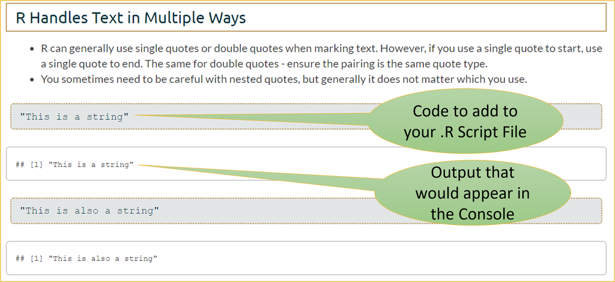

Reading our HTML file

# R is an Interactive Calculator

- An important facet of R is that it should serve as your sole calculator.
- Try these commands in your .R file by typing them in and clicking Ctr + Enter on each line.

```r
3 + 4
```

```
## [1] 7
```

```r
3 * 4
```

```
## [1] 12
```

```r
3/4
```

```
## [1] 0.75
```

```r
3 + 4 * 100^2
```

```
## [1] 40003
```

- Take note that order of operations holds in R: Parentheses ( ), Exponents ^, Division / and Multiplication *, Addition + and Subtraction -.
- There are a few ways to run commands via your .R file.
  - You can click Ctr + Enter on each line.
  - You can select all the lines you want to run and select Ctr + Enter.
  - You can select all the lines you want to run and select the run button as shown in the Figure.

[figure not shown]

Run Code

- Now that I have asked you to add a couple lines of code, after this point, when R code is shown on this file, you should add it to your .R script file along with any notes you want. I won’t explicitly say - “add this code.”
- Next, we are going to bridge this to terms in statistics with the Observations and Variables section.